# Homework 1 Question 1 by Nasibe Deniz & Merve Esin

Nasibe Deniz & Merve Esin

# Question 1-A

We ran the following 9 pieces of code to find out how many points will be in the hypersphere given the spesific number of dimensions.

**nof_samples=1000**

# 2 Dimensions

**datapoints2=runif(nof_samples*2,-1,1)**

**Mdatapoints2=matrix(datapoints2,ncol=2)**

**plot(Mdatapoints2)**

**euclidian_distance2=sqrt((Mdatapoints2[,1])^2 + (Mdatapoints2[,2])^2)**

**is_in_hypersphere2=euclidian_distance2<=1**

**nof_hypersphere2=sum(is_in_hypersphere2)**

# 3 Dimensions

**datapoints3=runif(nof_samples*3,-1,1)**

**Mdatapoints3=matrix(datapoints3,ncol=3)**

**plot(Mdatapoints3)**

**euclidian_distance3=sqrt((Mdatapoints3[,1])^2 + (Mdatapoints3[,2])^2 + (Mdatapoints3[,3])^2)**

**is_in_hypersphere3=euclidian_distance3<=1**

**nof_hypersphere3=sum(is_in_hypersphere3)**

# 4 Dimensions

**datapoints4=runif(nof_samples*4,-1,1)**

**Mdatapoints4=matrix(datapoints4,ncol=4)**

**plot(Mdatapoints4)**

**euclidian_distance4=sqrt((Mdatapoints4[,1])^2 + (Mdatapoints4[,2])^2 + (Mdatapoints4[,3])^2 + (Mdatapoints4[,4])^2)**

**is_in_hypersphere4=euclidian_distance4<=1**

**nof_hypersphere4=sum(is_in_hypersphere4)**

# 5 Dimensions

**datapoints5=runif(nof_samples*5,-1,1)**

**Mdatapoints5=matrix(datapoints5,ncol=5)**

**plot(Mdatapoints5)**

**euclidian_distance5=sqrt((Mdatapoints5[,1])^2 + (Mdatapoints5[,2])^2 + (Mdatapoints5[,3])^2 + (Mdatapoints5[,4])^2 + (Mdatapoints5[,5])^2)**

**is_in_hypersphere5=euclidian_distance5<=1**

**nof_hypersphere5=sum(is_in_hypersphere5)**

# 6 Dimensions

**datapoints6=runif(nof_samples*6,-1,1)**

**Mdatapoints6=matrix(datapoints6,ncol=6)**

**plot(Mdatapoints6)**

**euclidian_distance6=sqrt((Mdatapoints6[,1])^2 + (Mdatapoints6[,2])^2 + (Mdatapoints6[,3])^2 + (Mdatapoints6[,4])^2 + (Mdatapoints6[,5])^2 + (Mdatapoints6[,6])^2)**

**is_in_hypersphere6=euclidian_distance6<=1**

**nof_hypersphere6=sum(is_in_hypersphere6)**

# 7 Dimensions

**datapoints7=runif(nof_samples*7,-1,1)**

**Mdatapoints7=matrix(datapoints7,ncol=7)**

**plot(Mdatapoints7)**

**euclidian_distance7=sqrt((Mdatapoints7[,1])^2 + (Mdatapoints7[,2])^2 + (Mdatapoints7[,3])^2 + (Mdatapoints7[,4])^2 + (Mdatapoints7[,5])^2 + (Mdatapoints7[,6])^2 + (Mdatapoints7[,7])^2)**

**is_in_hypersphere7=euclidian_distance7<=1**

**nof_hypersphere7=sum(is_in_hypersphere7)**

# 8 Dimensions

**datapoints8=runif(nof_samples*8,-1,1)**

**Mdatapoints8=matrix(datapoints8,ncol=8)**

**plot(Mdatapoints8)**

**euclidian_distance8=sqrt((Mdatapoints8[,1])^2 + (Mdatapoints8[,2])^2 + (Mdatapoints8[,3])^2 + (Mdatapoints8[,4])^2 + (Mdatapoints8[,5])^2 + (Mdatapoints8[,6])^2 + (Mdatapoints8[,7])^2 + (Mdatapoints8[,8])^2)**

**is_in_hypersphere8=euclidian_distance8<=1**

**nof_hypersphere8=sum(is_in_hypersphere8)**

# 9 Dimensions

**datapoints9=runif(nof_samples*9,-1,1)**

**Mdatapoints9=matrix(datapoints9,ncol=9)**

**plot(Mdatapoints9)**

**euclidian_distance9=sqrt((Mdatapoints9[,1])^2 + (Mdatapoints9[,2])^2 + (Mdatapoints9[,3])^2 + (Mdatapoints9[,4])^2 + (Mdatapoints9[,5])^2 + (Mdatapoints9[,6])^2 + (Mdatapoints9[,7])^2 + (Mdatapoints9[,8])^2 + (Mdatapoints9[,9])^2)**

**is_in_hypersphere9=euclidian_distance9<=1**

**nof_hypersphere9=sum(is_in_hypersphere9)**

# 10 Dimensions

**datapoints=runif(nof_samples*10,-1,1)**

**Mdatapoints=matrix(datapoints,ncol=10)**

**plot(Mdatapoints)**

**euclidian_distance=sqrt((Mdatapoints7[,1])^2 + (Mdatapoints7[,2])^2 + (Mdatapoints7[,3])^2 + (Mdatapoints7[,4])^2 + (Mdatapoints7[,5])^2 + (Mdatapoints[,6])^2 + (Mdatapoints[,7])^2 + (Mdatapoints[,8])^2 + (Mdatapoints[,9])^2 + (Mdatapoints[,10])^2)**

**is_in_hypersphere=euclidian_distance<=1**

**nof_hypersphere10=sum(is_in_hypersphere)**

The amount of points in the hypersphere diminishes with the dimensions. Below are the number of points we found that are in the corresponding hypersphere. The number at the end denotes the number of dimensions.

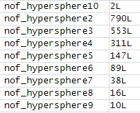

We can see that as the dimensions increase we have less and less points in the corresponding hypersphere. Since the formula gets longer and longer, the results become greater than the radius of the hypersphere which is 1. This demonstrates the curse of dimensionality well.

# Question 1-B

**estimated_pi_two_dimension=4*nof_hypersphere2/nof_samples**

**print(estimated_pi_two_dimension)**

**estimated_pi_three_dimension=(nof_hypersphere3/nof_samples)*8*(3/4)**

**print(estimated_pi_three_dimension)**

We ran the above formula and got the following results

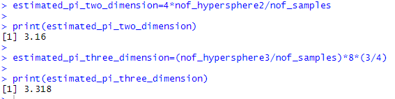

Using the two dimensional data clearly estimates the value of pi better. We can see that as the dimensions increase, it becomes more difficult to estimate pi accurately. This also demonstrates the curse of dimensionality.

[Link to our code](https://github.com/ETM-58D/spring20-nsbdeniz)  
[Link to our code](https://github.com/ETM-58D/spring20-mmerveesin)

Nasibe Deniz & Merve Esin